# Cherry Blossom Q 10

Daniel Byrne

9/21/2019

## Analysis

```r
# Load data
files = sapply(1999:2012,function(year){paste0("./MensResults",year,".csv")})
load.files = function(fileName) {
  read.csv(fileName,stringsAsFactors = FALSE)
}
mensResults = do.call(rbind,lapply(files, load.files))

## Convert to number
mensResults$Age = as.numeric(mensResults$Age)
## Convert to factor
mensResults$Race = sapply(mensResults$Race,function(x) {
  r = strsplit(x, " ")[[1]][1]
  return (r)
})
mensResults$Race = as.factor(mensResults$Race)
mensResults = mensResults %>% select("Race","Name","Age")
head(mensResults)
```

```
##   Race                  Name Age
## 1 1999      Worku Bikila (M)  28
## 2 1999 Lazarus Nyakeraka (M)  24
## 3 1999     James Kariuki (M)  27
## 4 1999    William Kiptum (M)  28
## 5 1999     Joseph Kimani (M)  26
## 6 1999   Josphat Machuka (M)  25
```

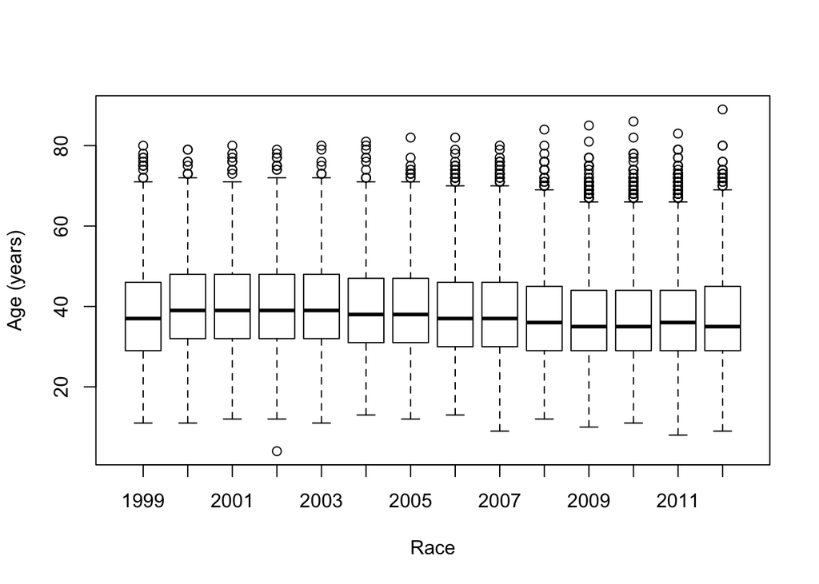

```r
plot(Age ~Race, data = mensResults, ylab = "Age (years)", xlab = "Race")
```

```r
stats = favstats(Age ~ Race,data=mensResults)
print(stats, type="html")
```

Race min Q1 median Q3 max mean sd n missing 1 1999 11 29 37 46 80 38.11654 10.48660 4608 2 2 2000 11 32 39 48 79 40.31884 10.53879 3036 0 3 2001 12 32 39 48 80 40.22070 10.61274 3575 3 4 2002 4 32 39 48 79 40.22567 10.71086 3740 3 5 2003 11 32 39 48 80 40.30272 10.75946 3941 2 6 2004 13 31 38 47 81 39.26027 10.95626 4161 0 7 2005 12 31 38 47 82 39.49862 11.06214 4334 10 8 2006 13 30 37 46 82 38.85837 10.95428 5253 1 9 2007 9 30 37 46 80 38.42407 11.14361 5235 2 10 2008 12 29 36 45 84 37.74072 10.91028 5924 0 11 2009 10 29 35 44 85 37.34128 10.80149 6672 0 12 2010 11 29 35 44 86 36.94730 10.76840 6926 4 13 2011 8 29 36 44 83 37.49822 10.85949 7029 0 14 2012 9 29 35 45 89 37.72720 10.86866 7214 1

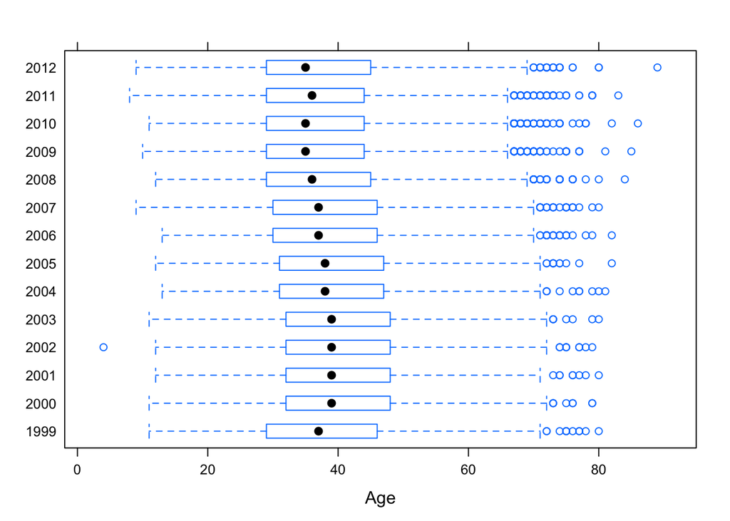

```r
bwplot(Race ~Age,data=mensResults)
```

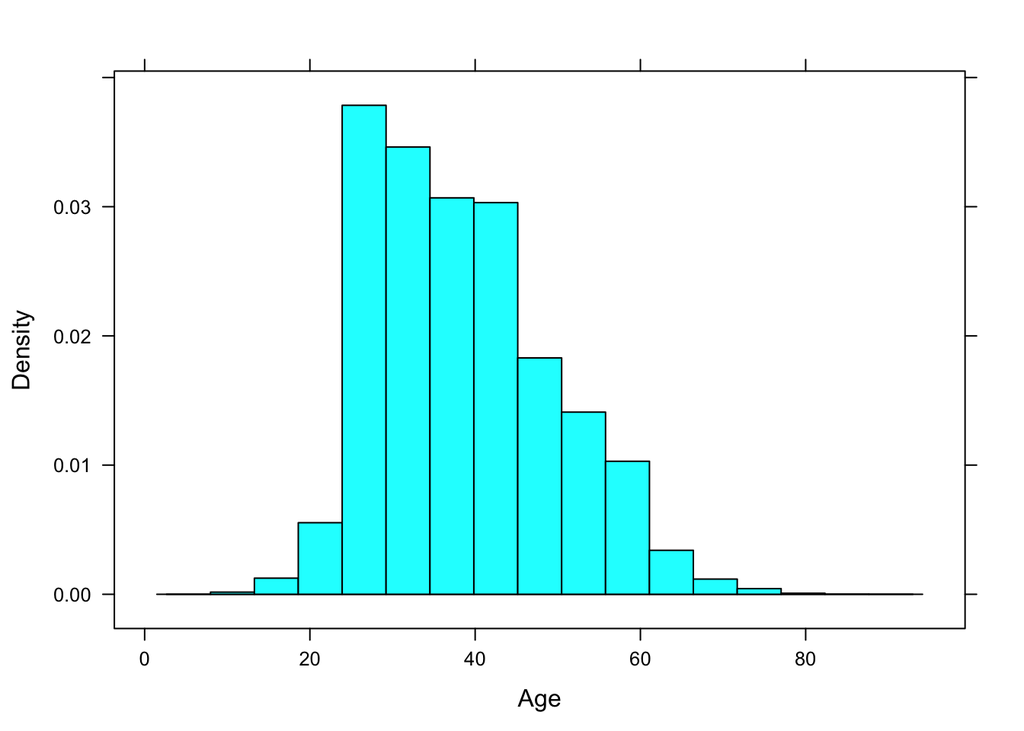

```r
histogram(~Age, data = mensResults)
```

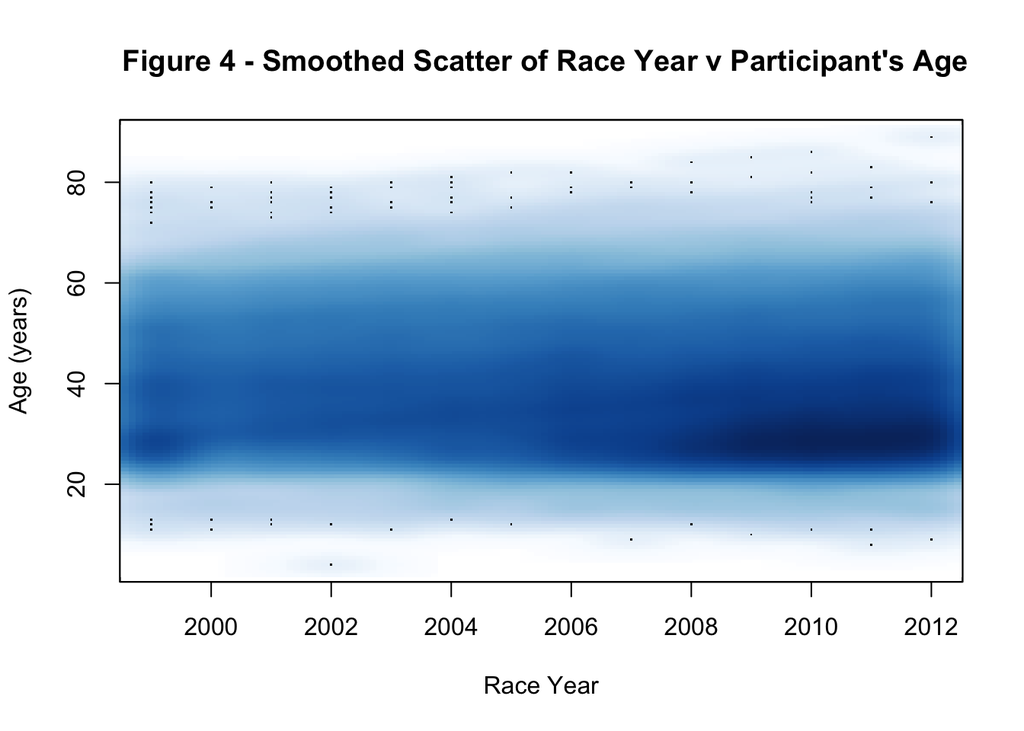

```r
smoothScatter(y = mensResults$Age, x = as.character(mensResults$Race),ylab = "Age (years)", xlab = "Race Year", main=" Figure 4 - Smoothed Scatter of Race Year v Participant's Age")
```

## One-way ANOVA

We fit the one way analysis of variance (ANOVA) model, using all of the groups.

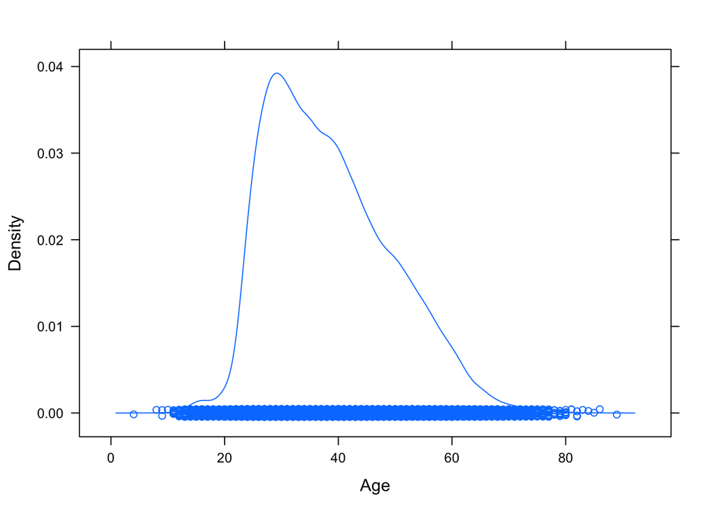

```r
densityplot(~Age,data=mensResults)
```

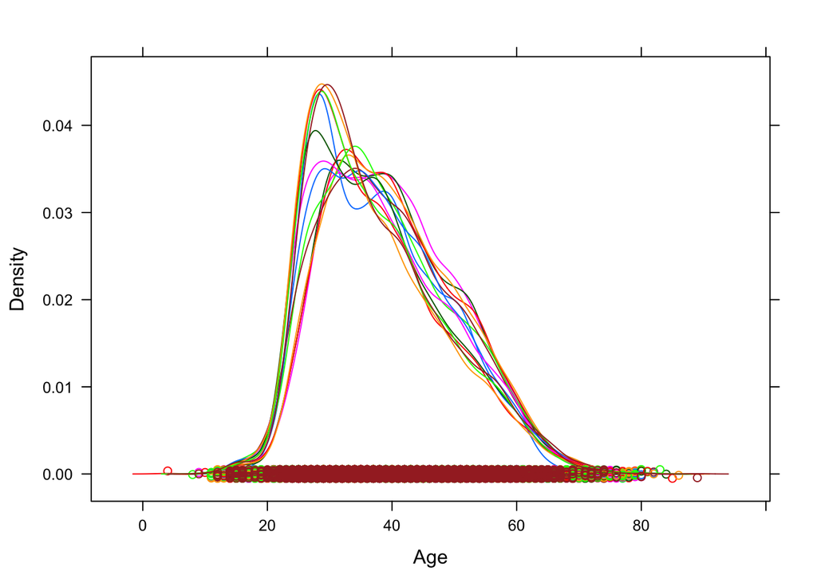

```r
densityplot(~Age,groups = Race,data=mensResults)
```

```r
anova(lm(Age ~ Race, data=mensResults))
```

```
## Analysis of Variance Table
##
## Response: Age
##              Df  Sum Sq Mean Sq F value    Pr(>F)
## Race         13   92977  7152.1  60.932 < 2.2e-16 ***
## Residuals 71634 8408324   117.4
## ---
## Signif. codes:  0 '***' 0.001 '**' 0.01 '*' 0.05 '.' 0.1 ' ' 1
```

The p-value provides some evidence that there ius a stistical difference between the mean age of participants over sucessive years of the race. By default, the use of the linear model function displays the pairwise differences between the first group (Race 1999) and each of the other groups.

```r
summary(lm(Age~Race,data=mensResults))
```

```
##
## Call:
## lm(formula = Age ~ Race, data = mensResults)
##
## Residuals:
##     Min      1Q  Median      3Q     Max
## -36.226  -8.498  -1.727   7.142  51.273
##
## Coefficients:
##             Estimate Std. Error t value Pr(>|t|)
## (Intercept)  38.1165     0.1596 238.822  < 2e-16 ***
## Race2000      2.2023     0.2532   8.696  < 2e-16 ***
## Race2001      2.1042     0.2415   8.714  < 2e-16 ***
## Race2002      2.1091     0.2384   8.845  < 2e-16 ***
## Race2003      2.1862     0.2351   9.300  < 2e-16 ***
## Race2004      1.1437     0.2317   4.936 7.98e-07 ***
## Race2005      1.3821     0.2293   6.029 1.66e-09 ***
## Race2006      0.7418     0.2187   3.392 0.000693 ***
## Race2007      0.3075     0.2188   1.405 0.159958
## Race2008     -0.3758     0.2128  -1.766 0.077398 .
## Race2009     -0.7753     0.2075  -3.736 0.000187 ***
## Race2010     -1.1692     0.2060  -5.677 1.38e-08 ***
## Race2011     -0.6183     0.2054  -3.011 0.002606 **
## Race2012     -0.3893     0.2043  -1.906 0.056706 .
## ---
## Signif. codes:  0 '***' 0.001 '**' 0.01 '*' 0.05 '.' 0.1 ' ' 1
##
## Residual standard error: 10.83 on 71634 degrees of freedom
##   (28 observations deleted due to missingness)
## Multiple R-squared:  0.01094,    Adjusted R-squared:  0.01076
## F-statistic: 60.93 on 13 and 71634 DF,  p-value: < 2.2e-16
```

## Pairwise Comparisons

The model table below displays the differences between the grand mean and the group means.

```r
results = model.tables(aov(lm(Age ~ Race,data=mensResults)))
results$tables
```

$Race Race 1999 2000 2001 2002 2003 2004 -0.3393869 1.8629172 1.7647759 1.7697450 1.8467916 0.8043506 2005 2006 2007 2008 2009 2010 1.0426922 0.4024432 -0.0318546 -0.7152077 -1.1146464 -1.5086234 2011 2012 -0.9577018 -0.7287263

## Residual Analysis

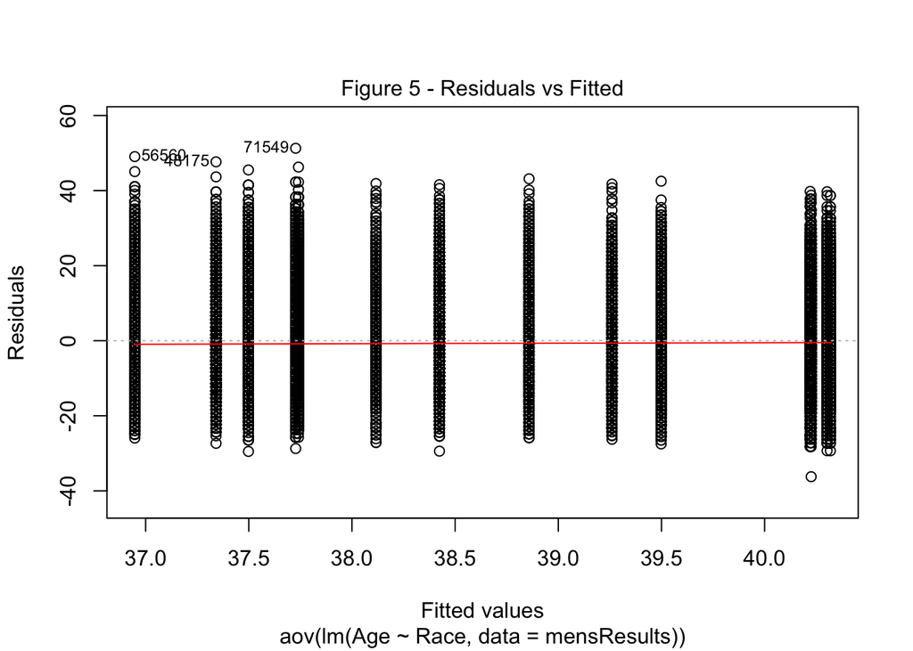

```r
aov1 = aov(lm(Age ~ Race, data=mensResults))
plot(aov1,which=1,"Figure 5 - Residuals vs Fitted")
```

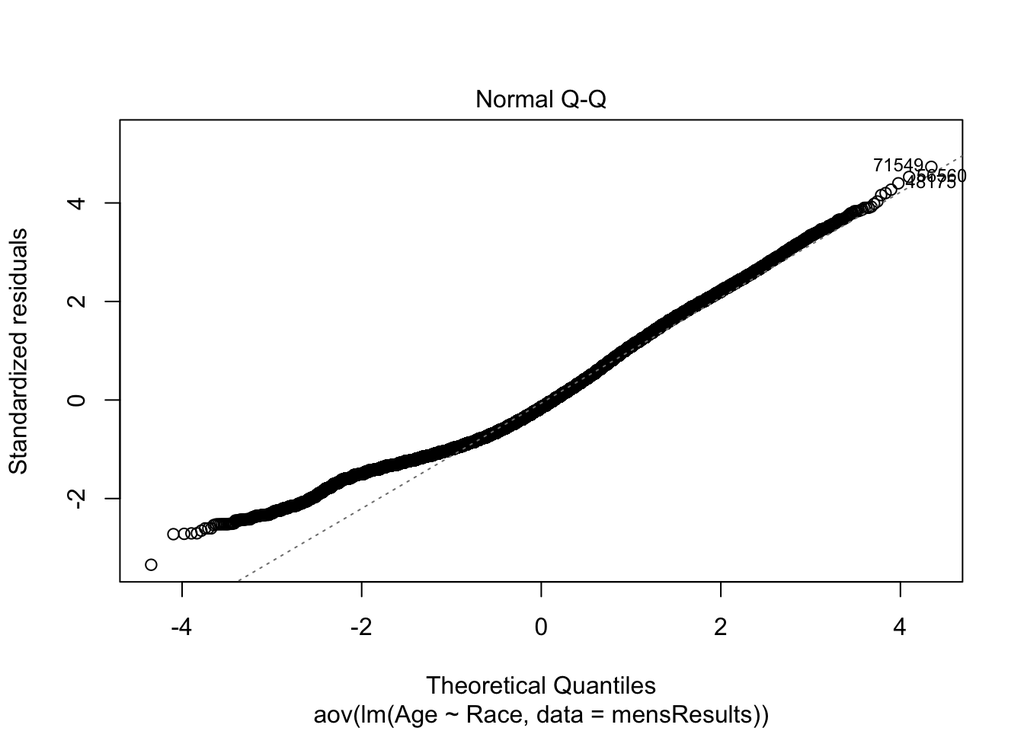

```r
plot(aov1,which=2)
```

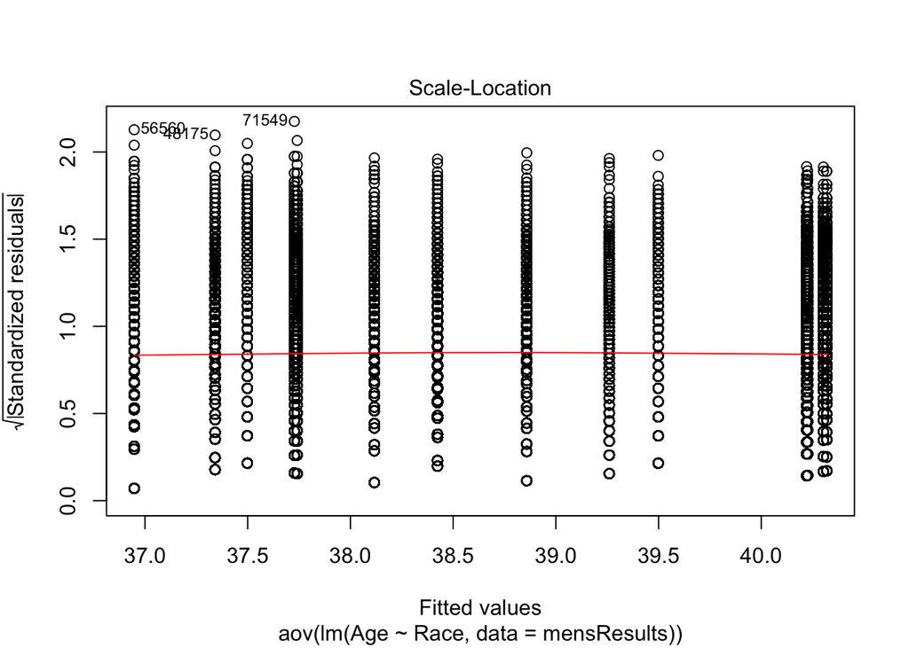

```r
plot(aov1,which=3)
```

```r
dw = durbinWatsonTest(lm(Age ~ Race,data=mensResults))
```